# Proyecto Final

Tomás Ignacio Marina

2026-11-12

## Interacciones Tróficas en el Océano Atlántico Sudoccidental

Utilizaremos el paquete de R rglobi para extraer los datos de la base de datos Global Biotic Interactions (GloBI). La función get_interactions_in_area() nos permite acotar la búsqueda a la región de interés, el Océano Atlántico Sudoccidental (OAS). Además, incorporaremos datos que corresponden a una zona particular del OAS, el Banco Burdwood (BB).

```r
# Cargar las librerías necesarias
library(rglobi)
library(dplyr)

# Definir los límites del Océano Atlántico Sudoccidental (bbox)
# left: -67.266667, bottom: -60.000000, right: -20.000000, top: 5.000000
bbox_atlantico_so <- c(-67.266667, -60.000000, -20.000000, 5.000000)

# Obtener todas las interacciones registradas en el área delimitada desde GloBI
interacciones_area <- get_interactions_in_area(bbox = bbox_atlantico_so)

# Filtrar y estandarizar los datos de rglobi
tipos_troficos <- c("eats", "preysOn", "eatenBy", "preyedUponBy")

rglobi_estandarizado <- interacciones_area %>%
  filter(interaction_type %in% tipos_troficos) %>%
  mutate(
    # Asignar Consumer y Resource dependiendo de la dirección de la interacción
    Consumer = ifelse(interaction_type %in% c("eats", "preysOn"), source_taxon_name, target_taxon_name),
    Resource = ifelse(interaction_type %in% c("eats", "preysOn"), target_taxon_name, source_taxon_name),
    Location = "OAS",
    Data_source = "rglobi"
  ) %>%
  # Conservar únicamente las columnas solicitadas
  select(Resource, Consumer, Location, Data_source)

# Cargar el archivo CSV local con interacciones adicionales
datos_burdwood <- read.csv("ListaInteracciones_BurdwoodBank.csv", stringsAsFactors = FALSE)

# Estandarizar los datos locales de Banco Burdwood
burdwood_estandarizado <- datos_burdwood %>%
  select(Resource, Consumer) %>%
  mutate(
    Location = "BB",
    Data_source = "local"
  )

# Integrar ambos data frames estandarizados en uno solo
interacciones_troficas <- bind_rows(rglobi_estandarizado, burdwood_estandarizado)
```

## Estructura y Primeras Filas de los Datos Estandarizados

A continuación, extraemos el nombre de las columnas (el encabezado) para entender qué variables tenemos a disposición y luego visualizamos los primeros 5 registros de nuestra tabla estandarizada y combinada.

Estructura: Cada fila representa una observación única de una interacción entre dos organismos. Variables clave:

Resource: Indica el nombre científico de la especie que actúa como presa o recurso alimenticio.

Consumer: Indica el nombre científico de la especie que actúa como depredador o consumidor (interpretado a partir del rol ecológico original de cada base de datos).

Location: Especifica la región espacial de la interacción, asignando OAS para los datos generales del Océano Atlántico Sudoccidental y BB para los registros específicos del Banco Burdwood.

Data_source: Señala si el registro proviene de la consulta a la API (rglobi) o del archivo proporcionado por el usuario (local).

```r
# Mostrar el encabezado (nombres de las variables)
names(interacciones_troficas)
```

```
## [1] "Resource"    "Consumer"    "Location"    "Data_source"
```

```r
# Mostrar las primeras 5 filas del data frame
head(interacciones_troficas, 5)
```

```
##          Resource            Consumer Location Data_source
## 1 Bacillariophyta Metridia curticauda      OAS      rglobi
## 2 Bacillariophyta Metridia curticauda      OAS      rglobi
## 3          Oncaea   Euphausia frigida      OAS      rglobi
## 4          Oncaea   Euphausia frigida      OAS      rglobi
## 5         Calanus   Euphausia frigida      OAS      rglobi
```

## Gráficos Exploratorios

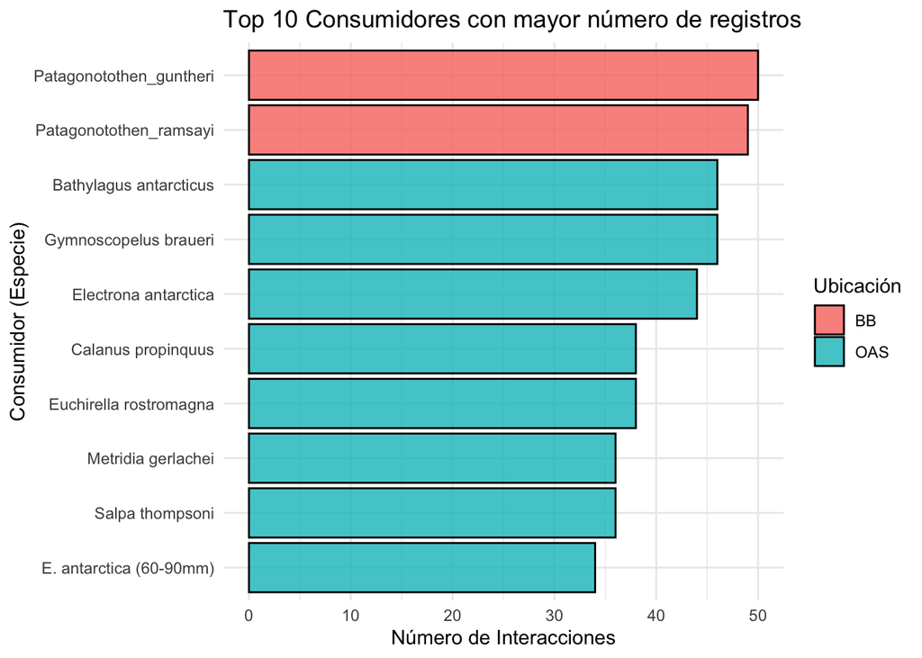

```r
# Cargar las librerías necesarias
library(ggplot2)

# 1. Gráfico de Barras: Top 10 Consumidores con más registros
# Primero identificamos las 10 especies con más registros globales
top_10_especies <- interacciones_troficas %>%
  count(Consumer, sort = TRUE) %>%
  head(10) %>%
  pull(Consumer)

# Luego filtramos los datos para esos top 10 y contamos agregando la variable Location
top_consumidores_loc <- interacciones_troficas %>%
  filter(Consumer %in% top_10_especies) %>%
  count(Consumer, Location)

# Graficamos usando el fill para diferenciar Location
ggplot(top_consumidores_loc, aes(x = factor(Consumer, levels = rev(top_10_especies)), y = n, fill = Location)) +
  geom_col(color = "black", alpha = 0.8) +
  coord_flip() + # Invertir ejes para facilitar la lectura de especies
  labs(title = "Top 10 Consumidores con mayor número de registros",
       x = "Consumidor (Especie)",
       y = "Número de Interacciones",
       fill = "Ubicación") +
  theme_minimal()
```

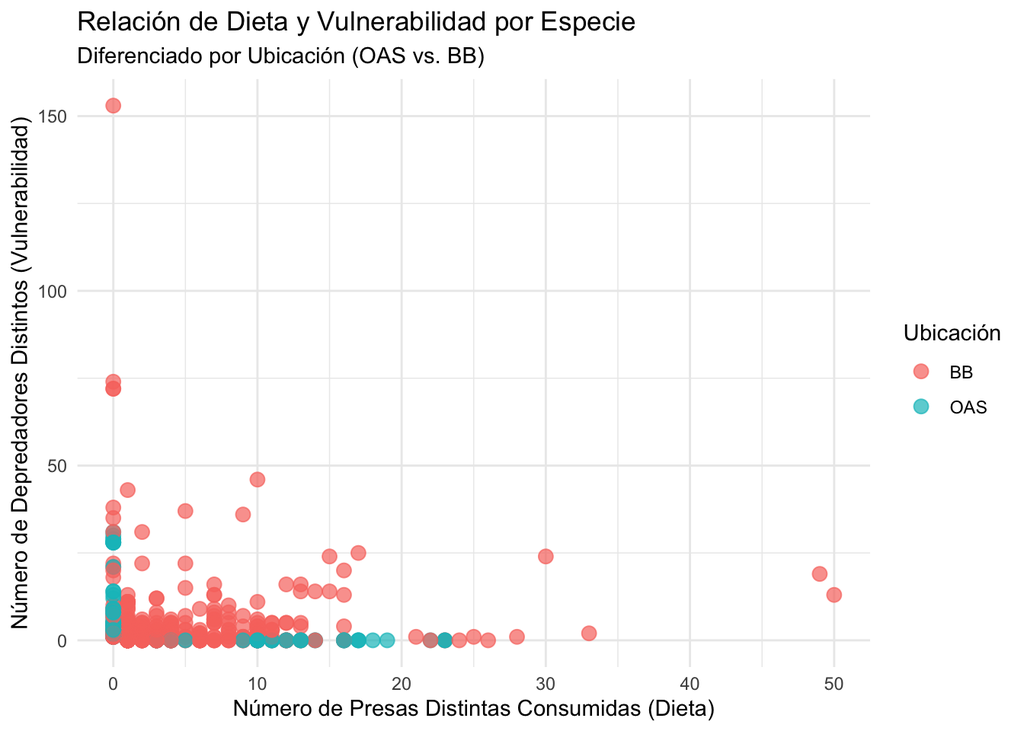

```r
# 2. Gráfico de Dispersión: Presas vs Depredadores por especie y ubicación
# Contar presas por consumidor y ubicación
presas_por_consumidor <- interacciones_troficas %>%
  group_by(Consumer, Location) %>%
  summarise(Num_Presas = n_distinct(Resource, na.rm = TRUE), .groups = "drop") %>%
  rename(Especie = Consumer)

# Contar depredadores por presa y ubicación
depredadores_por_presa <- interacciones_troficas %>%
  group_by(Resource, Location) %>%
  summarise(Num_Depredadores = n_distinct(Consumer, na.rm = TRUE), .groups = "drop") %>%
  rename(Especie = Resource)

# Unir ambas métricas para cada especie y ubicación; reemplazar los NA con 0
grado_especies <- full_join(presas_por_consumidor, depredadores_por_presa, by = c("Especie", "Location")) %>%
  mutate(
    Num_Presas = ifelse(is.na(Num_Presas), 0, Num_Presas),
    Num_Depredadores = ifelse(is.na(Num_Depredadores), 0, Num_Depredadores)
  )

# Crear el gráfico de dispersión con color mapeado a Location
ggplot(grado_especies, aes(x = Num_Presas, y = Num_Depredadores, color = Location)) +
  geom_point(alpha = 0.7, size = 3) +
  labs(title = "Relación de Dieta y Vulnerabilidad por Especie",
       subtitle = "Diferenciado por Ubicación (OAS vs. BB)",
       x = "Número de Presas Distintas Consumidas (Dieta)",
       y = "Número de Depredadores Distintos (Vulnerabilidad)",
       color = "Ubicación") +
  theme_minimal()
```

## Dos Funciones Sencillas

### Función 1: Estandarizar Datos de rglobi

```r
# Cargar las librerías necesarias
library(rglobi)
library(dplyr)

# Función 1: Estandarizar Datos de rglobi
# Definir la función
estandarizar_rglobi <- function(datos_crudos) {
  tipos_troficos <- c("eats", "preysOn", "eatenBy", "preyedUponBy")

  datos_estandarizados <- datos_crudos %>%
    filter(interaction_type %in% tipos_troficos) %>%
    mutate(
      # Asignar Consumer y Resource dependiendo de la dirección de la interacción
      Consumer = ifelse(interaction_type %in% c("eats", "preysOn"), source_taxon_name, target_taxon_name),
      Resource = ifelse(interaction_type %in% c("eats", "preysOn"), target_taxon_name, source_taxon_name),
      Data_source = "rglobi"
    ) %>%
    # Conservar únicamente las columnas solicitadas
    select(Resource, Consumer, Data_source)

  return(datos_estandarizados)
}
# Aplicar la función al data frame de interacciones tróficas
lista_estandar <- estandarizar_rglobi(interacciones_area)
# Mostrar la tabla resultante
print(head(lista_estandar))
```

```
##          Resource            Consumer Data_source
## 1 Bacillariophyta Metridia curticauda      rglobi
## 2 Bacillariophyta Metridia curticauda      rglobi
## 3          Oncaea   Euphausia frigida      rglobi
## 4          Oncaea   Euphausia frigida      rglobi
## 5         Calanus   Euphausia frigida      rglobi
## 6         Calanus   Euphausia frigida      rglobi
```

### Función 2: Contar Recursos y Consumidores

```r
# Cargar las librerías necesarias
library(rglobi)
library(dplyr)

# Función 2: Contar Especies Únicas
# Definir la función
contar_especies_unicas <- function(datos) {
  datos %>%
    summarise(
      Resource = n_distinct(Resource, na.rm = TRUE),
      Consumer = n_distinct(Consumer, na.rm = TRUE)
    )
}
# Aplicar la función al data frame de interacciones tróficas
resumen_especies <- contar_especies_unicas(interacciones_troficas)
# Mostrar la tabla resultante
print(resumen_especies)
```

```
##   Resource Consumer
## 1      302      378
```